# Coursework Report

*N* removed NAs: 2

*N* removed typo: 1

*N* removed <18: 24

*N* total clean: 123

| Group | *N* | *M*<sub>age</sub> | *M*<sub>rating</sub> |
| --- | --- | --- | --- |
| Control | 64 | 21.53 | 6.91 |
| Experim | 59 | 20.98 | 5.84 |

**Main analysis results**

*t*(121) = 7.41, *p* < .001

[interactive chart not shown]

[figure not shown]

[interactive chart not shown]

# Coursework Report

Analysing Data, Spring 2020

# Methods

## Participants

Table 1 *Descriptive statistics table of age by condition*

| Condition | *N* | % | *M*<sub>age</sub> | *SD*<sub>age</sub> |
| --- | --- | --- | --- | --- |
| control | 64 | 52.03 | 21.53 | 2.38 |
| experimental | 59 | 47.97 | 20.98 | 2.30 |

## Design

The main idea this study aims to test is whether colour influences attractiveness. The design used for this experiment was a between-subjects design as each participant took part in only one condition. The participants saw an image of an averagely attractive Caucasian man on either a red or white background, red being the experimental condition and white the control condition. In this study, colour is the independent categorical variable and has two levels, red (experimental) and white (control). The Attractiveness rating the participant gave is the continuous variable. The attractiveness rating of the man was on a scale from 1-9 (1= unattractive and 9 = very attractive) on three questions. The 3 questions which the participants were asked were, “How attractive do you think this person is?” “How pleasant is this person to look at?” and “If I were to meet the person in this picture face to face, I would think he is attractive”. This experiment was specifically interested in further researching if ratings of attractiveness of an averagely attractive man are influenced by putting a different colour frame around the image. To analyse this data I will create a composite score of each participant three-question ratings, create a means plot of this composite score by condition and perform a statistical t-test.

# Results

We first wanted to know the average attractiveness scores each participant gave the man. A composite score was calculated (Table 2), this found the average attractiveness rating score that the participants gave to the man in the photograph. This was worked out by finding the mean of the scores from the 3 questions participants were asked. In addition to this, we also worked out the mean ratings of each group. The experimental group had a mean score of 5.84, whereas the control condition had a mean score of 6.91. This suggests that the participants in the control (white) group found the man to be more attractive than those in the experimental (red) group. These results can be seen in the plot (figure 3). The t-test carried out on the data shows that there is a significant difference between the ratings in the red and white colour groups (*M*<sub>diff</sub> = 1.07, 95% CI [0.78, 1.36],*t* (121) = 7.41,*p* = <.oo1). This means that the null hypothesis can be rejected as the control white group found the man more attractive than the experimental red group.

Table 2 *composite of attractivness rating by partisipant.*

| ID | Question 1 | Question 2 | Question 3 | attractivness composite |
| --- | --- | --- | --- | --- |
| FJJH | 6 | 8 | 7 | 7.00 |
| GNGW | 8 | 5 | 5 | 6.00 |
| PVWY | 4 | 4 | 5 | 4.33 |
| QJSN | 9 | 5 | 8 | 7.33 |
| XEYZ | 7 | 8 | 7 | 7.33 |
| BUXZ | 5 | 5 | 8 | 6.00 |
| XWXD | 4 | 9 | 8 | 7.00 |
| RCJI | 6 | 6 | 9 | 7.00 |
| OEHA | 6 | 4 | 4 | 4.67 |
| LWAO | 4 | 6 | 8 | 6.00 |
| LOWV | 7 | 6 | 5 | 6.00 |
| AQQB | 7 | 4 | 8 | 6.33 |
| ANBW | 6 | 5 | 5 | 5.33 |
| TXQL | 7 | 3 | 6 | 5.33 |
| WMTH | 4 | 5 | 5 | 4.67 |
| CYIR | 7 | 9 | 6 | 7.33 |
| ZNJE | 6 | 6 | 7 | 6.33 |
| IBLR | 6 | 5 | 4 | 5.00 |
| TWNI | 8 | 6 | 7 | 7.00 |
| RAVR | 6 | 4 | 7 | 5.67 |
| XBPP | 4 | 4 | 5 | 4.33 |
| MPFW | 5 | 6 | 5 | 5.33 |
| DSXI | 5 | 7 | 6 | 6.00 |
| KDPF | 6 | 7 | 5 | 6.00 |
| EBTX | 6 | 7 | 6 | 6.33 |
| FANG | 7 | 7 | 6 | 6.67 |
| OQDX | 5 | 5 | 6 | 5.33 |
| QHOU | 5 | 7 | 7 | 6.33 |
| KYDO | 6 | 4 | 8 | 6.00 |
| QPYP | 5 | 6 | 6 | 5.67 |

[output cut: 93 more lines]

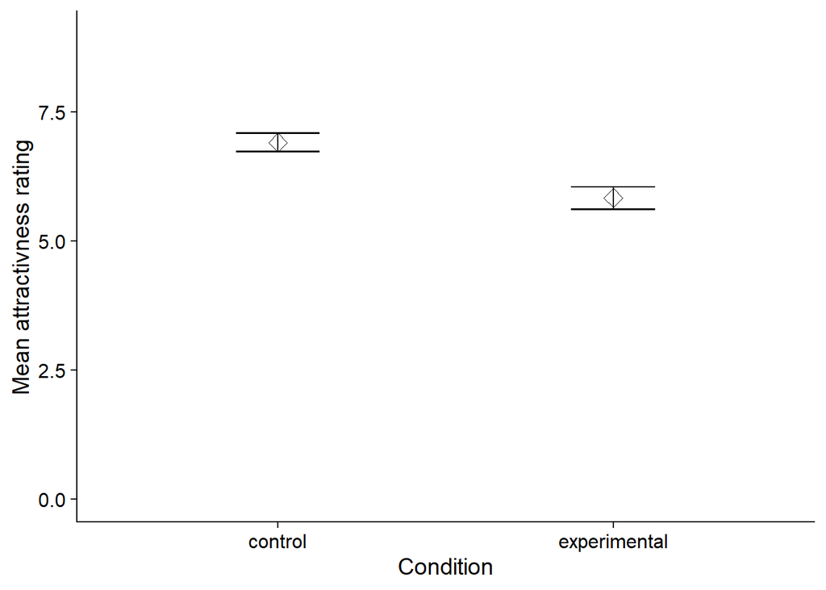

Figure 3 *A plot to show the mean attractivness rating by contition.*

# Discussion

Many studies have investigated the role of the colour red in the attractiveness ratings that men give to women. The main aim of this research, however, was to further investigate whether colour influences attractiveness. Specifically, we wanted to know if putting a different coloured background border around an averagely attractive man’s face would have an influence on attractiveness ratings given to him by women. This study is a close replication of a study by Elliot, Kayser, Greitemeyer, Lichtenfeld, Gramzow, Maier and Liu, (2010). The results of our study have found that colour does in fact influence attractiveness ratings with the white background leading to a higher attractiveness rating then red. These results contradicted those that were found in the study by Elliot et al, (2010) which brings up questions about the validity of the colour effect on attractiveness.

Interestingly in another close replication of Elliot et al, (2010) study, Hesslinger, Goldbach and Carbon, (2015), they found that their results were not significant, meaning that colour was not found to affect attractiveness ratings given by the women. This therefore again draws into question the validity of the results found within the experiments and the actual effect of colour on attractiveness, as our replication and another have not produced the same results. This has been looked at in-depth in Gregory, (2013) finding a strong likelihood that publication biases affected the results of Elliot et al, (2010) possibly showing why our studies results do not line up with the original. In addition to this, Elliot and Maier, (2013) did a similar method but used grey as the control colour. Within this study, the red condition did rate the man as more attractive although the results were not found as a large enough difference to be significant. However, it may suggest that using the colour white may have more of a positive effect on attractiveness than grey. Conversely, a study by Peperkoorn, Roberts and Pollet, (2016) which looked at colour effects of men’s ratings of women also found that the photographs in which the women were wearing the colour white were rated as more attractive than those in red or black. This is interesting as it possibly further suggests a new link with white and attractiveness and suggesting a possible reason for our findings. Another study (Guéguen & Jacob, 2012) which looked at changes in colour’s of t-shirts of women’s internet adverts found that more men responded to those women in red than any of the other colour’s in the study. This shows some contradiction to our findings, but it is also interesting to note that white was also one of the higher scoring colour’s and again maybe pointing to a reason that within replicas of the study by Elliot et al, (2010) there have been mixed results. Black was the least chosen colour condition showing that some colours can have a negative effect. These studies of internet style dating scenarios are interesting as it bought in the idea of online dating to make the study more ecologically valid. This could be a good way for more studies on this colour effect to progress in the future looking at whether different colours affect the likelihood of men and women swiping right on an averagely attractive person for example. I think that there is further space to investigate this as it would be interesting to see the effects of women to men and not just men to women. It would also be interesting to focus not only on the colour’s that have a positive effect other than just red but also at colour’s that have a negative effect on attractiveness ratings.

The fact that multiple close replications of this study have revealed different results brings into question the strength of the study design. For this study, in particular, I think one problem that affected the results could be that over 20 participants within the study had to be removed due to being underage. This meant that there was a different number of people in each group with more in the control group which may have influenced the mean results. To help solve this issue the next study could have a limit on age so that people under the age of 18 could not participate. Furthermore, the scale that was used to rate the attractiveness was reasonably basic and so if the study was performed again it would be a good idea to choose a more extensive attractiveness rating. For example, asking more detailed questions to get more of an insight as done in Peperkoorn et al, (2016) in which they asked about sexual attraction and faithfulness. From looking at other studies it is also clear that limiting the colours tested to white and red was a mistake as white has often been found to have a positive effect on attractiveness ratings influencing our results. In future research, I would suggest using multiple different colours to be able to better test the effect of colour and red specifically compared to other colours.

So, it has been shown that colour can influence attractiveness ratings, however, it is not always significant. Specifically, for this research white leads to a higher attractiveness rating then red. From this discussion, it can also be concluded that further research needs to be conducted to discover more about the effects of a broader range of colours in a more ecologically valid environment and with a more extensive questioning process.

# References

Elliot , A., Kayser, D., Greitemeyer, T., Lichtenfeld, S., Gramzow, R., Maier, M., & Liu, H. (2010). Red, Rank, and Romance in Women Viewing Men. Journal of Experimental Psychology: General , 139(3), 399 – 417.

Elliot, A., Maier, M.(2013) The red-attractiveness effect, applying the Ioannidis and Trikalinos (2007b) test, and the broader scientific context: A reply to Francis (2013). Journal of Experimental Psychology: General 142(1), 297-300. DOI:10.1037/a0029592

Gregory, F. (2013). Publication bias in “Red, rank, and romance in women viewing men,” by Elliot et al. (2010). Journal of Experimental Psychology: General, 142(1), 292-296.

Guéguen, N., Jacob, C. (2012). Color and cyber‐attractiveness: Red enhances men’s attraction to women’s internet personal ads. Colour research and aplication, 38(4), 309-312.

Hesslinger, V.M., Goldbach, L. & Carbon, C. (2015). Men in red: A reexamination of the red-attractiveness effect. Psychon Bull Rev 22, 1142–1148. https://doi.org/10.3758/s13423-015-0866-8

Peperkoorn, L., Roberts, C., Pollet, T.(2016). Revisiting the Red Effect on Attractiveness and Sexual Receptivity: No Effect of the Color Red on Human Mate Preferences. Evolutionary psychology, 14(4).